# 4 Geometric processing

In this chapter we give an overview of some of the advanced geometric processing features of the framework, highlighting the ones that will be most useful in future chapters.

From now on, we will assume that the main module of the framework is loaded in all code examples:

```julia
using GeoStats
```

We will also assume that the Makie.jl backend is loaded:

```julia
import CairoMakie as Mke
```

## 4.1 Geometries

We provide a vast list of geometries, which are organized into two main classes, `Primitive` and `Polytope` geometries. A geometry is a `Primitive` if it can be represented efficiently without discretization. For example, we can represent a `Box` with two corner points or a `Ball` with center and radius:

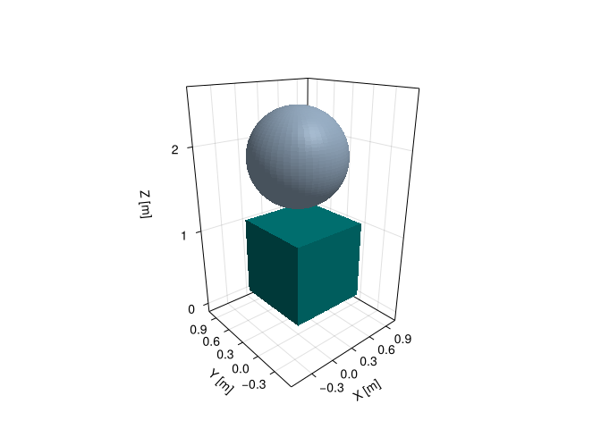

```julia
box = Box((0, 0, 0), (1, 1, 1))
ball = Ball((0, 0, 2), 0.5)

viz([box, ball], color = ["teal", "slategray3"])
```

Other examples include the `Cylinder`:

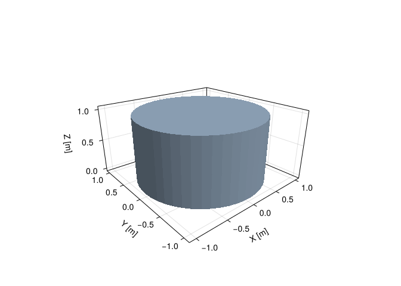

```julia
cyl = Cylinder(1.0)

viz(cyl)
```

And the `Torus`:

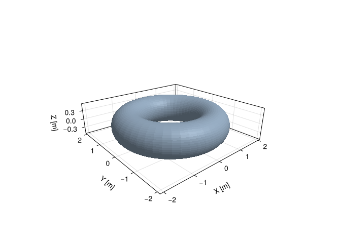

```julia
torus = Torus((1, 1, 0), (-1, -1, 0), (1, -1, 0), 0.5)

viz(torus)
```

The full list can be obtained with Julia’s `subtypes` function:

```julia
subtypes(Primitive)
```

```
20-element Vector{Any}:
 Ball
 BezierCurve
 Box
 Circle
 Cone
 ConeSurface
 Cylinder
 CylinderSurface
 Disk
 Ellipsoid
 Frustum
 FrustumSurface
 Line
 Paraboloid
 ParametrizedCurve
 Plane
 Point
 Ray
 Sphere
 Torus
```

**Note**

Geometries have their own documentation. For example, to learn more about the `Cylinder` geometry, its parameters and defaults, we can type the following in the Julia REPL:

```julia
?Cylinder
```

A geometry is a `Polytope` if it can be represented as a combination of “flat sides”, which are also `Polytope` themselves. A 3D `Polytope` is called a `Polyhedron`, a 2D `Polytope` is called a `Polygon` and a 1D `Polytope` is called a polygonal `Chain`. All these geometries are represented internally with a list of vertices.

First, let’s take a look into the `Polyhedron` geometries:

```julia
subtypes(Polyhedron)
```

```
4-element Vector{Any}:
 Hexahedron
 Pyramid
 Tetrahedron
 Wedge
```

The `Hexahedron` is a generalization of a 3D `Box` in the sense that it doesn’t need to be aligned with the coordinate system:

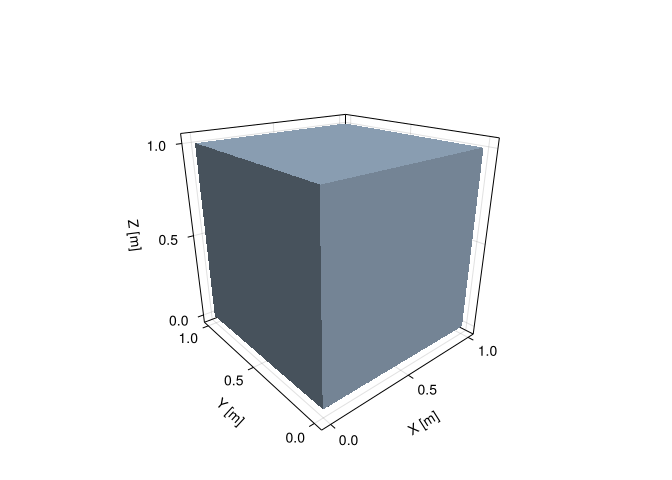

```julia
hex = Hexahedron((0, 0, 0), (1, 0, 0), (1, 1, 0), (0, 1, 0),
                 (0, 0, 1), (1, 0, 1), (1, 1, 1), (0, 1, 1))

viz(hex)
```

In this case, we need to store all the 8 vertices instead of just the corner points. Other examples of `Polyhedron` include the `Tetrahedron` and the `Pyramid`.

Now, let’s move to the `Polygon` geometries:

```julia
subtypes(Polygon)
```

```
2-element Vector{Any}:
 Ngon
 Pgon
```

We provide two types of `Polygon` that meet different application requirements.

The `Ngon` is a polygon without holes. Its vertices are stored in static memory, and they are mostly used for discretization of other geometries and geospatial domains. We provide type aliases to construct `Ngon` with a specific number `N` of vertices:

`Triangle`, `Quadrangle`, `Pentagon`, …, `Decagon`

The `Quadrangle` is a generalization of the 2D `Box` in the sense that it doesn’t need to be aligned with the coordinate system:

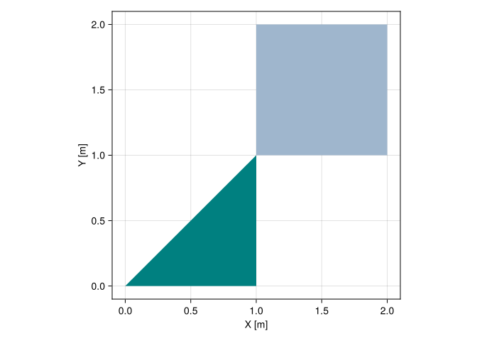

```julia
t = Triangle((0, 0), (1, 0), (1, 1))
q = Quadrangle((1, 1), (2, 1), (2, 2), (1, 2))

viz([t, q], color = ["teal", "slategray3"])
```

The `Pgon` is a polygon with or without holes. Its vertices are stored in dynamic memory, and they are mostly used for representation of areas in GIS:

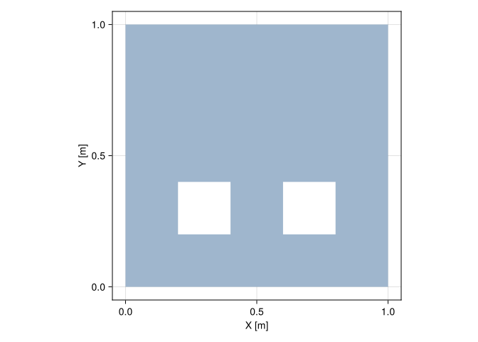

```julia
outer = [(0.0, 0.0), (1.0, 0.0), (1.0, 1.0), (0.0, 1.0)]
hole1 = [(0.2, 0.2), (0.2, 0.4), (0.4, 0.4), (0.4, 0.2)]
hole2 = [(0.6, 0.2), (0.6, 0.4), (0.8, 0.4), (0.8, 0.2)]
poly  = Pgon([outer, hole1, hole2])

viz(poly)
```

In the example above, the first list of vertices represents the external boundary of the `Pgon`, also known as the outer `Ring`. The other two lists represent the two internal boundaries, or inner rings. A single list of vertices can be used, in which case the `Pgon` doesn’t have holes.

**Note**

The topology of a 2D `Polygon` is defined by the `orientation` of its rings. Most geometric processing algorithms expect counter clockwise (`CCW`) orientation for the outer ring, and clockwise (`CW`) orientation for the inner rings:

```julia
r = rings(poly)

orientation.(r)
```

```
3-element Vector{OrientationType}:
 CCW::OrientationType = 1
 CW::OrientationType = 0
 CW::OrientationType = 0
```

**NoteTip for all users**

The `Repair` transform covered in the next chapter can be used to repair the orientations of rings in polygons.

Finally, let’s take a look into the polygonal `Chain`:

```julia
subtypes(Chain)
```

```
3-element Vector{Any}:
 Ring
 Rope
 Segment
```

These are 1-dimensional polytopes connecting `Point`s in sequence. We have seen the `Ring`s in the `Pgon` and `Ngon` geometries:

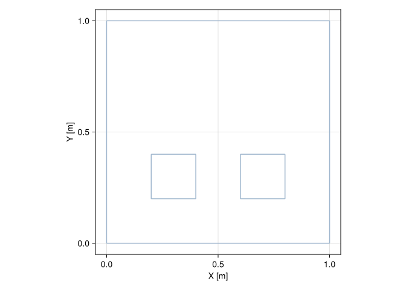

```julia
viz(r)
```

A `Ring` is closed meaning that its first and last `Point`s are connected with a `Segment`. A `Rope` is an open `Ring` without the closing `Segment`:

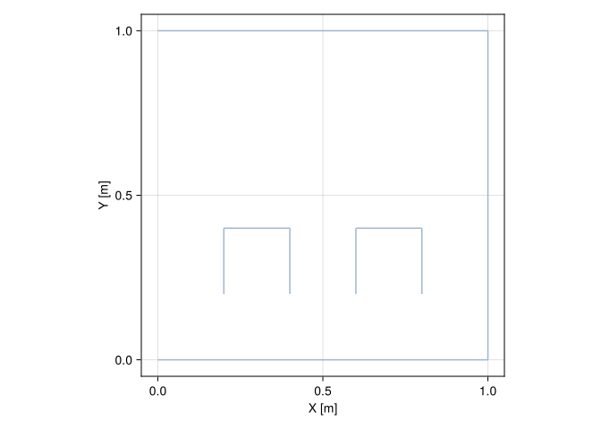

```julia
viz(open.(r))
```

We can obtain the list of segments of a `Chain` with the `segments` function:

```julia
collect(segments(first(r)))
```

```
4-element Vector{Segment{𝔼{2}, Cartesian2D{NoDatum, Quantity{Float64, 𝐋, Unitful.FreeUnits{(m,), 𝐋, nothing}}}}}:
 Segment((x: 0.0 m, y: 0.0 m), (x: 1.0 m, y: 0.0 m))
 Segment((x: 1.0 m, y: 0.0 m), (x: 1.0 m, y: 1.0 m))
 Segment((x: 1.0 m, y: 1.0 m), (x: 0.0 m, y: 1.0 m))
 Segment((x: 0.0 m, y: 1.0 m), (x: 0.0 m, y: 0.0 m))
```

The `Segment` geometry is a `Chain` with just 2 vertices:

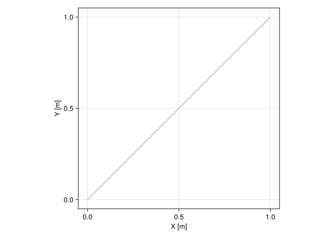

```julia
viz(Segment((0, 0), (1, 1)))
```

Finally, there is the `Multi`-geometry, which is a set of geometries seen as a single geometry. This is very common in GIS to represent disconnected areas on a geographic map that are related to each other (e.g., political areas):

```julia
Multi([Point(1, 2), Point(2, 3)])
```

```
Multi(2×Point)
├─ Point(x: 1.0 m, y: 2.0 m)
└─ Point(x: 2.0 m, y: 3.0 m)
```

```julia
Multi(r)
```

```
Multi(3×Ring)
├─ Ring((x: 0.0 m, y: 0.0 m), ..., (x: 0.0 m, y: 1.0 m))
├─ Ring((x: 0.2 m, y: 0.2 m), ..., (x: 0.4 m, y: 0.2 m))
└─ Ring((x: 0.6 m, y: 0.2 m), ..., (x: 0.8 m, y: 0.2 m))
```

```julia
Multi([t, q])
```

```
Multi(2×Ngon)
├─ Triangle((x: 0.0 m, y: 0.0 m), (x: 1.0 m, y: 0.0 m), (x: 1.0 m, y: 1.0 m))
└─ Quadrangle((x: 1.0 m, y: 1.0 m), ..., (x: 1.0 m, y: 2.0 m))
```

## 4.2 Predicates

Julia provides support for unicode characters in variable and function names. We leverage this feature to define commonly used geometric predicates with intuitive mathematical notation:

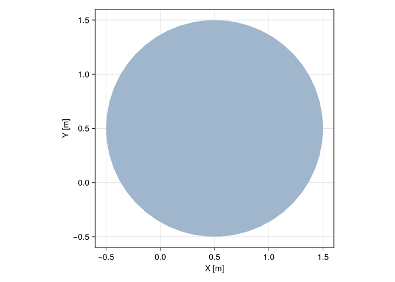

```julia
p = Point(0.0, 0.0)
b = Ball((0.5, 0.5), 1.0)

viz([p, b], color = ["teal", "slategray3"])
```

```julia
p ∈ b
```

```
true
```

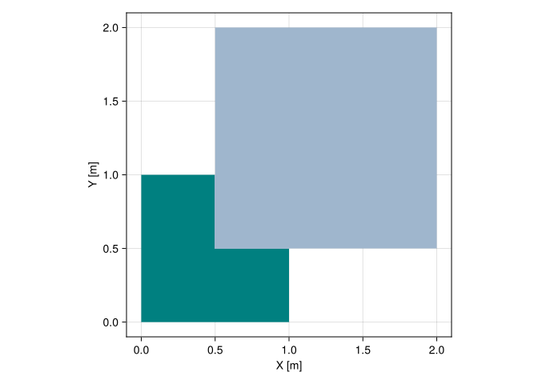

```julia
b1 = Box((0, 0), (1, 1))
b2 = Box((0.5, 0.5), (2, 2))

viz([b1, b2], color = ["teal", "slategray3"])
```

```julia
b1 ⊆ b2
```

```
false
```

**NoteTip for all users**

The symbol `∈` is obtained in Julia by typing `\in` and pressing the TAB key on the keyboard. We could have used the syntax `p in b` or `in(p, b)` as well. Similarly, the symbol `⊆` is obtained by typing `\subseteq`. We could have used the syntax `issubseteq(b1, b2)` as well.

If you don’t know the $\LaTeX$ name of a symbol, you can copy/paste it in the Julia REPL in help mode:

```julia
?∈
```

Some predicates don’t have well-established mathematical notation. For example, a polygon `issimple` if it doesn’t have holes nor self-intersections:

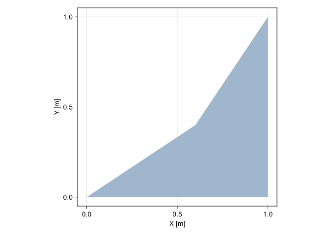

```julia
q = Quadrangle((0, 0), (1, 0), (1, 1), (0.6, 0.4))

viz(q)
```

```julia
issimple(q)
```

```
true
```

It `isconvex` if all line segments connecting two points of the polygon are inside the polygon:

```julia
isconvex(q)
```

```
false
```

A very useful predicate is `intersects` (with a “s” at the end):

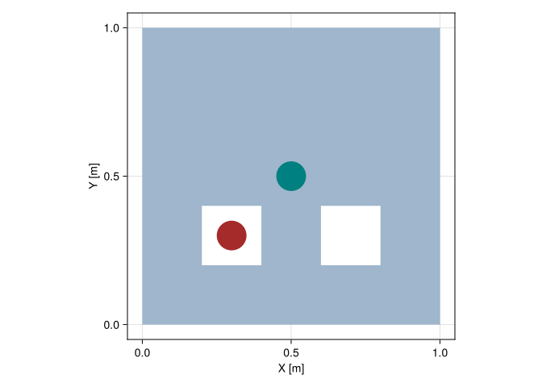

```julia
outer = [(0.0, 0.0), (1.0, 0.0), (1.0, 1.0), (0.0, 1.0)]
hole1 = [(0.2, 0.2), (0.2, 0.4), (0.4, 0.4), (0.4, 0.2)]
hole2 = [(0.6, 0.2), (0.6, 0.4), (0.8, 0.4), (0.8, 0.2)]
poly  = Pgon([outer, hole1, hole2])
ball1 = Ball((0.5, 0.5), 0.05)
ball2 = Ball((0.3, 0.3), 0.05)

viz([poly, ball1, ball2], color = ["slategray3", "teal", "brown"])
```

```julia
intersects(poly, ball1)
```

```
true
```

```julia
intersects(poly, ball2)
```

```
false
```

It tells whether or not the geometries intersect, without actually computing the intersection. The `intersection` itself is considered a geometric operation as discussed in the next section.

Please consult the official documentation for the full list of predicates.

## 4.3 Operations

Geometric operations transform a geometry or a set of geometries into a new geometry or number. For example, the intersection of two segments can be a `Point`, a `Segment` or `nothing`:

```julia
s1 = Segment((0.0, 0.0), (1.0, 0.0))
s2 = Segment((0.5, 0.0), (2.0, 0.0))

s1 ∩ s2
```

```
Segment
├─ Point(x: 0.5 m, y: 0.0 m)
└─ Point(x: 1.0 m, y: 0.0 m)
```

**NoteTip for advanced users**

For performance-sensitive applications, it is wise to replace the `∩` operation by its the 3-argument version named `intersection`:

```julia
intersection(s1, s2) do I
  if I == Crossing
    return 1
  else
    return 0
  end
end
```

```
0
```

The example above uses Julia’s do-syntax to define a function in place. The function takes the intersection type `I` and creates branches that return the same type (`Int` in this case) for type stability. The more we reduce the number of branches and types, the more the Julia compiler will be able to infer the output type.

Likewise, the intersection of two 2D geometries can be obtained with:

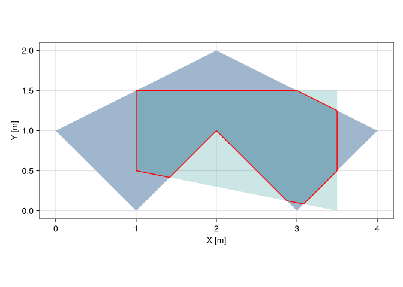

```julia
poly1 = Ngon((0, 1), (1, 0), (2, 1), (3, 0), (4, 1), (2, 2))
poly2 = Ngon((1.0, 0.5), (3.5, 0.0), (3.5, 1.5), (1.0, 1.5))

poly  = poly1 ∩ poly2

viz(poly1)
viz!(poly2, color = "teal", alpha = 0.2)
viz!(boundary(poly), color = "red")
Mke.current_figure()
```

The previous example makes use of the `boundary` of a geometry, which is very useful to know:

```julia
boundary(poly)
```

```
Ring
├─ Point(x: 1.4166666666666667 m, y: 0.4166666666666667 m)
├─ Point(x: 2.0 m, y: 1.0 m)
├─ Point(x: 2.875 m, y: 0.125 m)
├─ Point(x: 3.0833333333333335 m, y: 0.08333333333333333 m)
├─ Point(x: 3.5 m, y: 0.5 m)
├─ Point(x: 3.5 m, y: 1.25 m)
├─ Point(x: 3.0 m, y: 1.5 m)
├─ Point(x: 1.0 m, y: 1.5 m)
└─ Point(x: 1.0 m, y: 0.5 m)
```

Some operations like `measure` (`length`, `area` or `volume`) produce numbers instead of geometries. For example, the `area` of the polygon above is:

```julia
area(poly)
```

```
2.4479166666666665 m^2
```

The `measure` of the `boundary` is known as the `perimeter` of the geometry:

```julia
perimeter(poly)
```

```
7.598044863023599 m
```

All `Polytope` geometries have `vertices`:

```julia
vertices(poly)
```

```
9-element Vector{Point{𝔼{2}, Cartesian2D{NoDatum, Quantity{Float64, 𝐋, Unitful.FreeUnits{(m,), 𝐋, nothing}}}}}:
 Point(x: 1.4166666666666667 m, y: 0.4166666666666667 m)
 Point(x: 2.0 m, y: 1.0 m)
 Point(x: 2.875 m, y: 0.125 m)
 Point(x: 3.0833333333333335 m, y: 0.08333333333333333 m)
 Point(x: 3.5 m, y: 0.5 m)
 Point(x: 3.5 m, y: 1.25 m)
 Point(x: 3.0 m, y: 1.5 m)
 Point(x: 1.0 m, y: 1.5 m)
 Point(x: 1.0 m, y: 0.5 m)
```

Please consult the official documentation for the full list of operations.

## 4.4 Algorithms

Any other function that is not a predicate nor an operation is called a geometric processing “algorithm” in the framework. We provide a list of advanced algorithms for discretization, simplification, refinement, convex hull, etc.

Below we illustrate some of these algorithms, which will be useful in future examples:

```julia
points = rand(Point, 100, crs=Cartesian2D)
```

```
100-element Vector{Point{𝔼{2}, Cartesian2D{NoDatum, Quantity{Float64, 𝐋, Unitful.FreeUnits{(m,), 𝐋, nothing}}}}}:
 Point(x: 0.6582104084650332 m, y: 0.1447290485721714 m)
 Point(x: 0.21315564086214933 m, y: 0.3503664061760011 m)
 Point(x: 0.41642966049802865 m, y: 0.8599890064611302 m)
 Point(x: 0.9430332491096755 m, y: 0.21594771607607366 m)
 Point(x: 0.1079553601726333 m, y: 0.8449510603831789 m)
 Point(x: 0.6778744809460301 m, y: 0.197982422553154 m)
 Point(x: 0.7372873935347273 m, y: 0.6278072107777278 m)
 Point(x: 0.729477319228881 m, y: 0.9438342067032152 m)
 Point(x: 0.9329790659568753 m, y: 0.7238862953009708 m)
 Point(x: 0.7322839104406779 m, y: 0.246064681567443 m)
 ⋮
 Point(x: 0.045334134782754276 m, y: 0.7560996438165235 m)
 Point(x: 0.2756724592660055 m, y: 0.5659506298831306 m)
 Point(x: 0.7283873155923869 m, y: 0.05195806714104201 m)
 Point(x: 0.21019305087696905 m, y: 0.8895118275505359 m)
 Point(x: 0.46806384136425416 m, y: 0.4121210222134587 m)
 Point(x: 0.6035967571515914 m, y: 0.6948159464212801 m)
 Point(x: 0.06755910291890754 m, y: 0.35502142208771537 m)
 Point(x: 0.8317848825891727 m, y: 0.13832090010318387 m)
 Point(x: 0.7761196882865875 m, y: 0.11546880959541894 m)
```

**Note**

The `crs` option specifies the Coordinate Reference System (CRS) of the points. It will be explored in the chapter Map projections. By default, the `rand` function generates geometries with `Cartesian3D` CRS:

```julia
rand(Triangle, 3)
```

```
3-element Vector{Triangle{𝔼{3}, Cartesian3D{NoDatum, Quantity{Float64, 𝐋, Unitful.FreeUnits{(m,), 𝐋, nothing}}}}}:
 Triangle((x: 0.439879 m, y: 0.119976 m, z: 0.252688 m), (x: 0.109809 m, y: 0.46494 m, z: 0.14736 m), (x: 0.501647 m, y: 0.884677 m, z: 0.179072 m))
 Triangle((x: 0.283181 m, y: 0.580599 m, z: 0.0284752 m), (x: 0.171843 m, y: 0.0755899 m, z: 0.495219 m), (x: 0.434303 m, y: 0.944327 m, z: 0.873404 m))
 Triangle((x: 0.369892 m, y: 0.184271 m, z: 0.0672247 m), (x: 0.387237 m, y: 0.346135 m, z: 0.978514 m), (x: 0.943947 m, y: 0.453788 m, z: 0.953139 m))
```

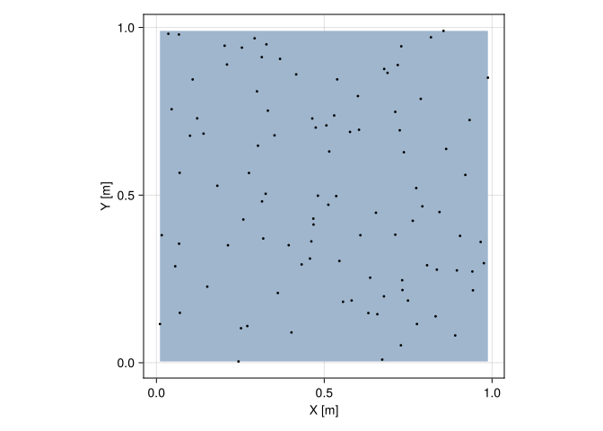

```julia
viz(boundingbox(points))
viz!(points, color = "black")
Mke.current_figure()
```

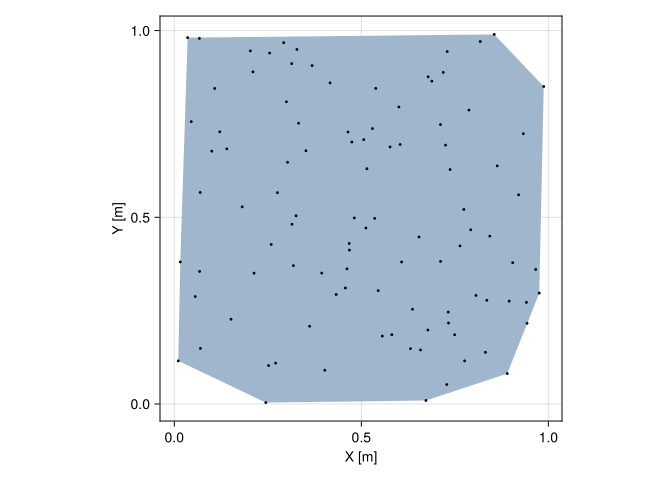

```julia
viz(convexhull(points))
viz!(points, color = "black")
Mke.current_figure()
```

Geometries can be discretized into geospatial domains (i.e., collections of geometries). We have seen some of these domains in previous chapters, including the `GeometrySet` and the `CartesianGrid`. Here, we will focus on the `Mesh` subtypes:

```julia
subtypes(Mesh)
```

```
5-element Vector{Any}:
 RectilinearGrid
 RegularGrid
 SimpleMesh
 StructuredGrid
 TransformedMesh
```

```julia
subtypes(Grid)
```

```
5-element Vector{Any}:
 RectilinearGrid
 RegularGrid
 SimpleMesh{M, C, V, GridTopology{N}} where {M<:Meshes.Manifold, C<:CRS, V<:AbstractArray{Point{M, C}, 1}, N}
 StructuredGrid
 TransformedMesh{M, C, GridTopology{N}} where {M<:Meshes.Manifold, C<:CRS, N}
```

There are two main functions to perform discretization: `discretize` and `simplexify`. The `discretize` function takes a geometry and a discretization algorithm as input, and produces a `Mesh`. For example, we can discretize a 2D ball with regular spacing along each parametric dimension (i.e., polar coordinates):

```julia
ball = Ball((0, 0), 1)

mesh = discretize(ball, RegularDiscretization(20, 50))
```

```
1050 SimpleMesh
  1051 vertices
  ├─ Point(x: 0.047619047619047616 m, y: 0.0 m)
  ├─ Point(x: 0.09523809523809523 m, y: 0.0 m)
  ├─ Point(x: 0.14285714285714285 m, y: 0.0 m)
  ├─ Point(x: 0.19047619047619047 m, y: 0.0 m)
  ├─ Point(x: 0.23809523809523808 m, y: 0.0 m)
  ⋮
  ├─ Point(x: 0.8503840296981238 m, y: -0.10742848591226112 m)
  ├─ Point(x: 0.8976275869035751 m, y: -0.11339673512960896 m)
  ├─ Point(x: 0.9448711441090264 m, y: -0.1193649843469568 m)
  ├─ Point(x: 0.9921147013144778 m, y: -0.12533323356430465 m)
  └─ Point(x: 0.0 m, y: 0.0 m)
  1050 elements
  ├─ Quadrangle(1, 2, 23, 22)
  ├─ Quadrangle(2, 3, 24, 23)
  ├─ Quadrangle(3, 4, 25, 24)
  ├─ Quadrangle(4, 5, 26, 25)
  ├─ Quadrangle(5, 6, 27, 26)
  ⋮
  ├─ Triangle(1051, 946, 967)
  ├─ Triangle(1051, 967, 988)
  ├─ Triangle(1051, 988, 1009)
  ├─ Triangle(1051, 1009, 1030)
  └─ Triangle(1051, 1030, 1)
```

We can visualize the elements of the mesh with the `showsegments` option:

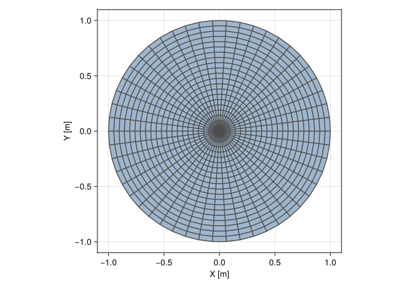

```julia
viz(mesh, showsegments = true)
```

The meshes produced by the `discretize` function can have mixed element types. In this case, the mesh is made of `Quadrangle` and `Triangle` geometries. The function `simplexify` is preferred if the application requires a mesh of simplices (i.e., triangles or tetrahedra):

```julia
tmesh = simplexify(ball)
```

```
250 SimpleMesh
  151 vertices
  ├─ Point(x: 0.3333333333333333 m, y: 0.0 m)
  ├─ Point(x: 0.6666666666666666 m, y: 0.0 m)
  ├─ Point(x: 1.0 m, y: 0.0 m)
  ├─ Point(x: 0.33070490043815925 m, y: 0.04177774452143475 m)
  ├─ Point(x: 0.6614098008763185 m, y: 0.0835554890428695 m)
  ⋮
  ├─ Point(x: 0.968583161128631 m, y: -0.24868988716485535 m)
  ├─ Point(x: 0.33070490043815925 m, y: -0.04177774452143488 m)
  ├─ Point(x: 0.6614098008763185 m, y: -0.08355548904286976 m)
  ├─ Point(x: 0.9921147013144778 m, y: -0.12533323356430465 m)
  └─ Point(x: 0.0 m, y: 0.0 m)
  250 elements
  ├─ Triangle(1, 2, 5)
  ├─ Triangle(1, 5, 4)
  ├─ Triangle(2, 3, 6)
  ├─ Triangle(2, 6, 5)
  ├─ Triangle(4, 5, 8)
  ⋮
  ├─ Triangle(151, 136, 139)
  ├─ Triangle(151, 139, 142)
  ├─ Triangle(151, 142, 145)
  ├─ Triangle(151, 145, 148)
  └─ Triangle(151, 148, 1)
```

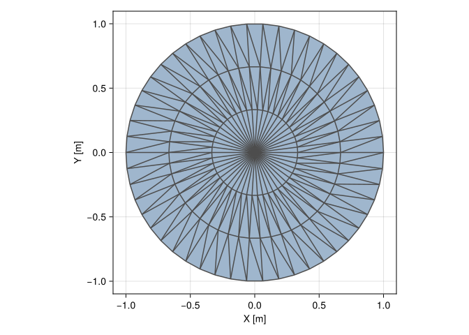

```julia
viz(tmesh, showsegments = true)
```

Various triangulation algorithms are provided such as `DehnTriangulation` (Devadoss and O’Rourke 2011), `DelaunayTriangulation` (Cheng et al. 2012) and `HeldTriangulation` (Held 2001). After the mesh is created, it is possible to `refine` the elements:

```julia
mesh = discretize(Box((0, 0), (1, 1)))
```

```
1×1 CartesianGrid
├─ minimum: Point(x: 0.0 m, y: 0.0 m)
├─ maximum: Point(x: 1.0 m, y: 1.0 m)
└─ spacing: (1.0 m, 1.0 m)
```

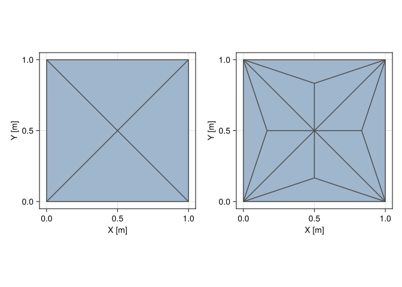

```julia
tmesh1 = refine(mesh, TriRefinement())
tmesh2 = refine(tmesh1, TriRefinement())

fig = Mke.Figure()
viz(fig[1, 1], tmesh1, showsegments = true)
viz(fig[1, 2], tmesh2, showsegments = true)
fig
```

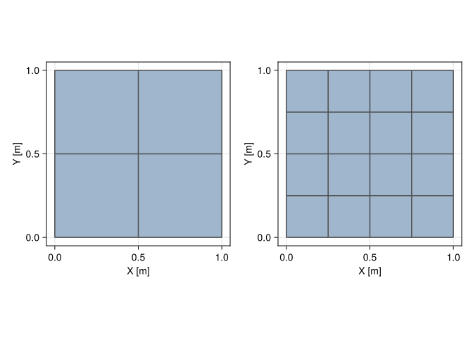

```julia
qmesh1 = refine(mesh, QuadRefinement())
qmesh2 = refine(qmesh1, QuadRefinement())

fig = Mke.Figure()
viz(fig[1, 1], qmesh1, showsegments = true)
viz(fig[1, 2], qmesh2, showsegments = true)
fig
```

We will have the chance to see more algorithms in action as we advance in the chapters of the book.

## 4.5 Domains

For most purposes, domains can be manipulated as if they were Julia vectors of geometries. As an example, we can compute the `centroid` of each geometry in the domain by broadcasting the function:

```julia
grid = CartesianGrid(2, 3)

centroid.(grid)
```

```
6-element Vector{Point{𝔼{2}, Cartesian2D{NoDatum, Quantity{Float64, 𝐋, Unitful.FreeUnits{(m,), 𝐋, nothing}}}}}:
 Point(x: 0.5 m, y: 0.5 m)
 Point(x: 1.5 m, y: 0.5 m)
 Point(x: 0.5 m, y: 1.5 m)
 Point(x: 1.5 m, y: 1.5 m)
 Point(x: 0.5 m, y: 2.5 m)
 Point(x: 1.5 m, y: 2.5 m)
```

In some cases, however, it is important to know which geometries are adjacent to a given geometry; or which geometries make up the boundary of a given geometry. This is where the `topology` is useful:

```julia
topo = topology(grid)
```

```
2×3 GridTopology(aperiodic, aperiodic)
```

We can create an `Adjacency` topological relation to find which quadrangles are adjacent to quadrangle `1` in the domain:

```julia
A = Adjacency{2}(topo)

A(1)
```

```
(2, 3)
```

The number `2` that appears in the `Adjacency` relation is known as the parametric dimension. In this case, we are interested in the adjacency of 2D geometries. The quadrangle `1` is the first quadrangle in the bottom-left corner of the grid, and it is adjacent to quadrangles `2` and `3`. As another example, the quadrangle `3` is adjacent to quadrangles `4`, `1` and `5`:

```julia
A(3)
```

```
(4, 1, 5)
```

In order to query the adjacency of vertices, we create a relation with parametric dimension `0`:

```julia
A = Adjacency{0}(topo)

A(1)
```

```
(2, 4)
```

We can also query the vertices that are on the boundary of a given quadrangle with the `Boundary` topological relation. In this case, we specify the parametric dimension of the input and output geometries:

```julia
B = Boundary{2,0}(topo)

B(1)
```

```
(1, 2, 5, 4)
```

Topological relations are an advanced feature of the framework. They are mostly used by developers of geostatistical algorithms, or in geospatial queries that will be covered in **Part III** of the book.

## 4.6 Congratulations!

Congratulations on finishing **Part I** of the book. Let’s quickly review what we learned so far:

- The main concept in geospatial data science is the concept of geospatial data, represented in the GeoStats.jl framework as geotables over geospatial domains.
- The geotable representation generalizes traditional GIS representations (“raster” vs. “vector”), and enables a unified approach to visualization and manipulation of geospatial data.
- It is still possible to interface with existing GIS technology via input and output of files using the GeoIO.jl module. A typical workflow will load GIS data at the beginning of a script, and save the result of the analysis at the end of the script.
- Geometric processing doesn’t need to be complicated. It should be fun and read like math. If it feels “computer sciency”, that is a limitation of the software and programming language.

We are finally ready to learn the advanced features of the framework. Let’s get it started.

Cheng, Siu-Wing, Tamal K. Dey, and Jonathan Shewchuk. 2012. *Delaunay Mesh Generation*. Chapman; Hall/CRC. https://people.eecs.berkeley.edu/~jrs/meshbook.html.

Devadoss, Satyan L, and Joseph O’Rourke. 2011. *Discrete and Computational Geometry*. Princeton University Press.

Held, M. 2001. “FIST: Fast Industrial-Strength Triangulation of Polygons.” *Algorithmica* 30 (4): 563–96. https://doi.org/10.1007/s00453-001-0028-4.